# Palmer Penguins Analysis

Daniel Eniola

2026-02-21

## Introduction

This report explores the **Palmer Penguins dataset**, which contains data on 344 penguins from three species — Adelie, Chinstrap, and Gentoo — observed across three islands in the Palmer Archipelago, Antarctica. The data were collected by Dr. Kristen Gorman.

The goal of this analysis is to examine the physical characteristics of each species, explore ecological differences across islands, and visualize key relationships within the dataset. This analysis demonstrates how exploratory data analysis and visualization can reveal biological differences among species and highlight ecological patterns across habitats.

## Setup

```r
library(tidyverse)
library(palmerpenguins)
```

## Data Exploration

```r
head(penguins)
```

```
## # A tibble: 6 × 8
##   species island    bill_length_mm bill_depth_mm flipper_length_mm body_mass_g
##   <fct>   <fct>              <dbl>         <dbl>             <int>       <int>
## 1 Adelie  Torgersen           39.1          18.7               181        3750
## 2 Adelie  Torgersen           39.5          17.4               186        3800
## 3 Adelie  Torgersen           40.3          18                 195        3250
## 4 Adelie  Torgersen           NA            NA                  NA          NA
## 5 Adelie  Torgersen           36.7          19.3               193        3450
## 6 Adelie  Torgersen           39.3          20.6               190        3650
## # ℹ 2 more variables: sex <fct>, year <int>
```

```r
nrow(penguins)
```

```
## [1] 344
```

```r
ncol(penguins)
```

```
## [1] 8
```

```r
glimpse(penguins)
```

```
## Rows: 344
## Columns: 8
## $ species           <fct> Adelie, Adelie, Adelie, Adelie, Adelie, Adelie, Adel…
## $ island            <fct> Torgersen, Torgersen, Torgersen, Torgersen, Torgerse…
## $ bill_length_mm    <dbl> 39.1, 39.5, 40.3, NA, 36.7, 39.3, 38.9, 39.2, 34.1, …
## $ bill_depth_mm     <dbl> 18.7, 17.4, 18.0, NA, 19.3, 20.6, 17.8, 19.6, 18.1, …
## $ flipper_length_mm <int> 181, 186, 195, NA, 193, 190, 181, 195, 193, 190, 186…
## $ body_mass_g       <int> 3750, 3800, 3250, NA, 3450, 3650, 3625, 4675, 3475, …
## $ sex               <fct> male, female, female, NA, female, male, female, male…
## $ year              <int> 2007, 2007, 2007, 2007, 2007, 2007, 2007, 2007, 2007…
```

### Checking for Missing Values

```r
colSums(is.na(penguins))
```

```
##           species            island    bill_length_mm     bill_depth_mm
##                 0                 0                 2                 2
## flipper_length_mm       body_mass_g               sex              year
##                 2                 2                11                 0
```

## Calculations

### Summary Statistics by Species

```r
penguins %>%
  group_by(species) %>%
  summarise(
    avg_bill_length = mean(bill_length_mm, na.rm = TRUE),
    mid_bill_length = median(bill_length_mm, na.rm = TRUE),
    min_bill_length = min(bill_length_mm, na.rm = TRUE),
    max_bill_length = max(bill_length_mm, na.rm = TRUE),
    sd_bill_length = sd(bill_length_mm, na.rm = TRUE),
    avg_flipper_length = mean(flipper_length_mm, na.rm = TRUE),
    mid_flipper_length = median(flipper_length_mm, na.rm = TRUE),
    min_flipper_length = min(flipper_length_mm, na.rm = TRUE),
    max_flipper_length = max(flipper_length_mm, na.rm = TRUE),
    sd_flipper_length = sd(flipper_length_mm, na.rm = TRUE)
  )
```

```
## # A tibble: 3 × 11
##   species   avg_bill_length mid_bill_length min_bill_length max_bill_length
##   <fct>               <dbl>           <dbl>           <dbl>           <dbl>
## 1 Adelie               38.8            38.8            32.1            46
## 2 Chinstrap            48.8            49.6            40.9            58
## 3 Gentoo               47.5            47.3            40.9            59.6
## # ℹ 6 more variables: sd_bill_length <dbl>, avg_flipper_length <dbl>,
## #   mid_flipper_length <dbl>, min_flipper_length <int>,
## #   max_flipper_length <int>, sd_flipper_length <dbl>
```

### Heaviest Island by Average Body Mass

```r
penguins %>%
  group_by(island) %>%
  summarise(avg_body_mass = mean(body_mass_g, na.rm = TRUE)) %>%
  arrange(-avg_body_mass)
```

```
## # A tibble: 3 × 2
##   island    avg_body_mass
##   <fct>             <dbl>
## 1 Biscoe            4716.
## 2 Dream             3713.
## 3 Torgersen         3706.
```

### Bill Ratio

```r
penguins <- penguins %>%
  mutate(bill_ratio = bill_length_mm / bill_depth_mm)
head(penguins)
```

```
## # A tibble: 6 × 9
##   species island    bill_length_mm bill_depth_mm flipper_length_mm body_mass_g
##   <fct>   <fct>              <dbl>         <dbl>             <int>       <int>
## 1 Adelie  Torgersen           39.1          18.7               181        3750
## 2 Adelie  Torgersen           39.5          17.4               186        3800
## 3 Adelie  Torgersen           40.3          18                 195        3250
## 4 Adelie  Torgersen           NA            NA                  NA          NA
## 5 Adelie  Torgersen           36.7          19.3               193        3450
## 6 Adelie  Torgersen           39.3          20.6               190        3650
## # ℹ 3 more variables: sex <fct>, year <int>, bill_ratio <dbl>
```

```r
penguins %>%
  select(species, bill_length_mm, bill_depth_mm, bill_ratio) %>%
  head()
```

```
## # A tibble: 6 × 4
##   species bill_length_mm bill_depth_mm bill_ratio
##   <fct>            <dbl>         <dbl>      <dbl>
## 1 Adelie            39.1          18.7       2.09
## 2 Adelie            39.5          17.4       2.27
## 3 Adelie            40.3          18         2.24
## 4 Adelie            NA            NA        NA
## 5 Adelie            36.7          19.3       1.90
## 6 Adelie            39.3          20.6       1.91
```

### Bill Ratio Analysis

```r
penguins %>%
  group_by(species) %>%
  summarise(avg_bill_ratio = mean(bill_ratio, na.rm = TRUE)) %>%
  arrange(-avg_bill_ratio)
```

```
## # A tibble: 3 × 2
##   species   avg_bill_ratio
##   <fct>              <dbl>
## 1 Gentoo              3.18
## 2 Chinstrap           2.65
## 3 Adelie              2.12
```

## Bill Ratio Visualization

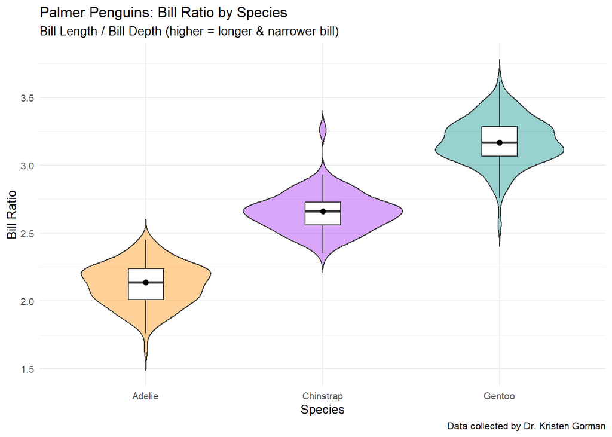

```r
ggplot(data = penguins) +
  geom_violin(mapping = aes(x = species, y = bill_ratio, fill = species),
    alpha = 0.4,
    trim = FALSE,
    na.rm = TRUE) +
  geom_boxplot(mapping = aes(x = species, y = bill_ratio),
    width = 0.2,
    fill = "white",
    outlier.shape = NA,
    na.rm = TRUE) +
  stat_summary(mapping = aes(x = species, y = bill_ratio),
    fun = "median",
    geom = "point",
    color = "black",
    size = 2,
    na.rm = TRUE) +
  scale_fill_manual(values = c("darkorange", "purple", "cyan4")) +
  labs(title = "Palmer Penguins: Bill Ratio by Species",
    subtitle = "Bill Length / Bill Depth (higher = longer & narrower bill)",
    x = "Species",
    y = "Bill Ratio",
    caption  = "Data collected by Dr. Kristen Gorman") +
  theme_minimal(base_size = 10) +
  theme(legend.position = "none")
```

### Male vs Female Count by Species

```r
penguins %>%
  filter(!is.na(sex)) %>%
  count(species, sex)
```

```
## # A tibble: 6 × 3
##   species   sex        n
##   <fct>     <fct>  <int>
## 1 Adelie    female    73
## 2 Adelie    male      73
## 3 Chinstrap female    34
## 4 Chinstrap male      34
## 5 Gentoo    female    58
## 6 Gentoo    male      61
```

### Male vs Female Percentage by Species

```r
penguins %>%
  filter(!is.na(sex)) %>%
  group_by(species, sex) %>%
  summarise(count = n(), .groups = "drop_last") %>%
  mutate(percentage = count / sum(count) * 100)
```

```
## # A tibble: 6 × 4
## # Groups:   species [3]
##   species   sex    count percentage
##   <fct>     <fct>  <int>      <dbl>
## 1 Adelie    female    73       50
## 2 Adelie    male      73       50
## 3 Chinstrap female    34       50
## 4 Chinstrap male      34       50
## 5 Gentoo    female    58       48.7
## 6 Gentoo    male      61       51.3
```

### Male vs Female Visualization

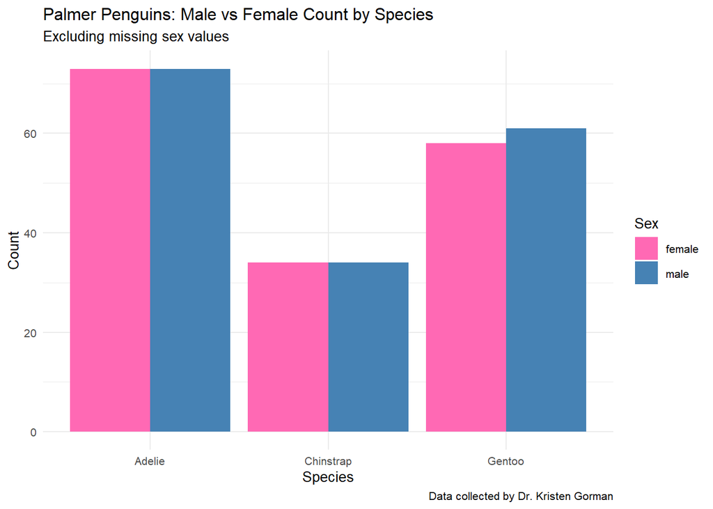

```r
penguins %>%
  filter(!is.na(sex)) %>%
  ggplot(mapping = aes(x = species, fill = sex)) +
  geom_bar(position = "dodge") +
  labs(title = "Palmer Penguins: Male vs Female Count by Species",
       subtitle = "Excluding missing sex values",
       x = "Species",
       y = "Count",
       fill = "Sex",
       caption = "Data collected by Dr. Kristen Gorman") +
  scale_fill_manual(values = c("female" = "hotpink", "male" = "steelblue")) +
  theme_minimal(base_size = 10)
```

### Island Biodiversity

```r
penguins %>%
  group_by(island, species) %>%
  summarise(count = n(), .groups = "drop")
```

```
## # A tibble: 5 × 3
##   island    species   count
##   <fct>     <fct>     <int>
## 1 Biscoe    Adelie       44
## 2 Biscoe    Gentoo      124
## 3 Dream     Adelie       56
## 4 Dream     Chinstrap    68
## 5 Torgersen Adelie       52
```

### Island Biodiversity Visualization

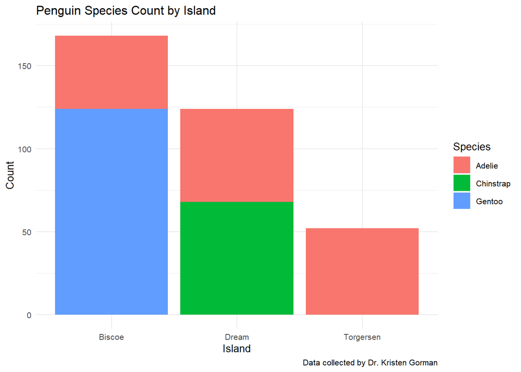

```r
penguins %>%
  group_by(island, species) %>%
  summarise(count = n(), .groups = "drop") %>%
  ggplot(mapping = aes(x = island, y = count, fill = species)) +
  geom_bar(stat = "identity") +
  labs(title = "Penguin Species Count by Island",
       x = "Island",
       y = "Count",
       fill = "Species",
       caption = "Data collected by Dr. Kristen Gorman") +
  theme_minimal(base_size = 10)
```

## Body Mass vs. Flipper Length Visualization

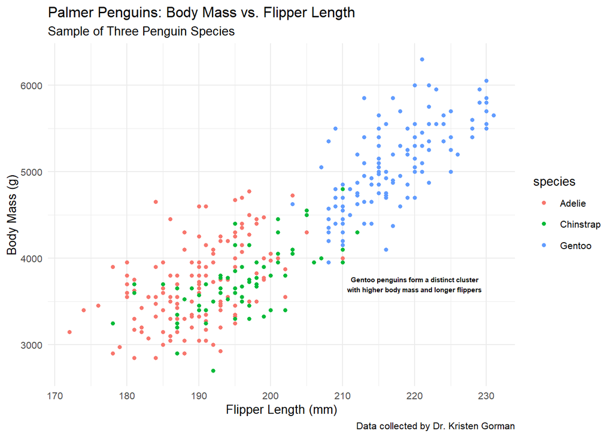

```r
ggplot(data = penguins) +
  geom_point(mapping = aes(x = flipper_length_mm, y = body_mass_g, colour = species), na.rm = TRUE) +
  labs(title = "Palmer Penguins: Body Mass vs. Flipper Length",
       x = "Flipper Length (mm)",
       y = "Body Mass (g)",
       subtitle = "Sample of Three Penguin Species",
       caption = "Data collected by Dr. Kristen Gorman") +
  annotate("text", x = 220, y = 3700,
           label =
             "Gentoo penguins form a distinct cluster\nwith higher body mass and longer flippers",
           colour = "black",
           fontface = "bold",
           size = 2) +
  theme_minimal(base_size = 10)
```

### Correlation Test: Flipper Length vs Body Mass

```r
cor.test(penguins$flipper_length_mm, penguins$body_mass_g,
         use = "complete.obs")
```

```
##
##  Pearson's product-moment correlation
##
## data:  penguins$flipper_length_mm and penguins$body_mass_g
## t = 32.722, df = 340, p-value < 2.2e-16
## alternative hypothesis: true correlation is not equal to 0
## 95 percent confidence interval:
##  0.843041 0.894599
## sample estimates:
##       cor
## 0.8712018
```

## Conclusions

Overall, the analysis reveals clear morphological differences among penguin species and strong relationships between physical traits and their habitat distribution.

**Which species tends to be the largest overall?** Gentoo penguins appear to be the largest species overall, exhibiting the highest average body mass and the longest flippers.

**Is there a statistically significant correlation between flipper length and body mass?** Yes — a Pearson correlation test confirms a strong positive correlation (r = 0.87, p < 0.001), meaning penguins with longer flippers significantly tend to have greater body mass.

**Which island has the most biodiversity?** Both Biscoe and Dream Islands host two penguin species each, making them equally biodiverse. Torgersen Island is the least biodiverse, hosting only Adelie penguins. Notably, Adelie is the only species found across all three islands.

**Which species has the highest bill ratio?** Gentoo penguins have the highest mean bill ratio (3.18), meaning they have longer, narrower bills relative to their depth. Adelie penguins have the lowest ratio (2.12), with shorter, deeper bills.

**What is the male vs female distribution across species?** The sex distribution is remarkably balanced — Adelie and Chinstrap penguins are exactly 50/50 male to female, while Gentoo penguins are very close at 48.7% female and 51.3% male.

Missing values were minimal and handled using na.rm = TRUE, ensuring that summary statistics and visualizations were not biased by incomplete observations.

## What I Learned

- How to perform exploratory data analysis (EDA) using tidyverse in R
- How to handle missing values using `na.rm = TRUE` and `filter(!is.na())`
- How to create and interpret multiple visualization types including violin plots, scatter plots, and bar charts using ggplot2
- How to engineer new features from existing data using `mutate()`
- How to quantify relationships between variables using `cor.test()`
- The importance of grouping data with `group_by()` before summarising
- How to use `arrange()`, `select()`, `count()`, and `summarise()` to explore and understand data

*Analysis completed by Daniel Eniola | Data source: palmerpenguins R package*